# Problem 3

```r
#Loading the GOTV dataset, and deriving its column names for future use
data("gotv")
#load(file='gotv.rda')
coln <- colnames(gotv)

#Creating the training and testing dataset
set.seed(14142)
ind <- sample(nrow(gotv), nrow(gotv)/5)
train <- gotv[-ind,]
test <- gotv[ind,]
```

## Part (a)

#### Calculating propensity score

We create a logistic regression model to determine W|X, and store the pScores in an array. I do not add the array to the gotv dataframe to preserve the GOTV dataset for later use.

```r
model_pscore <- glm(treatment ~ sex+g2000+g2002+p2000+p2002+p2004+age, family=binomial(link='logit'), data=gotv)
summary(model_pscore)
```

```
##
## Call:
## glm(formula = treatment ~ sex + g2000 + g2002 + p2000 + p2002 +
##     p2004 + age, family = binomial(link = "logit"), data = gotv)
##
## Deviance Residuals:
##     Min       1Q   Median       3Q      Max
## -0.6163  -0.6056  -0.6028  -0.5989   1.9185
##
## Coefficients:
##               Estimate Std. Error z value Pr(>|z|)
## (Intercept) -1.5720760  0.0222877 -70.536   <2e-16 ***
## sex         -0.0044788  0.0112169  -0.399   0.6897
## g2000       -0.0089967  0.0176012  -0.511   0.6093
## g2002        0.0134717  0.0162974   0.827   0.4085
## p2000        0.0134745  0.0131890   1.022   0.3070
## p2002       -0.0016152  0.0119574  -0.135   0.8925
## p2004       -0.0032659  0.0115201  -0.283   0.7768
## age         -0.0008191  0.0004279  -1.914   0.0556 .
## ---
## Signif. codes:  0 '***' 0.001 '**' 0.01 '*' 0.05 '.' 0.1 ' ' 1
##
## (Dispersion parameter for binomial family taken to be 1)
##
##     Null deviance: 206690  on 229460  degrees of freedom
## Residual deviance: 206685  on 229453  degrees of freedom
## AIC: 206701
##
## Number of Fisher Scoring iterations: 3
```

```r
pScores <- fitted(model_pscore)
```

#### Matching ATT

```r
rr  <- Match(Y = gotv$voted, Tr =gotv$treatment, X = pScores, M=1, version = 'fast', ties = FALSE)
```

The ATT estimate based on the Matching model is 0.0123502

#### Balance Plot

We store the p_values of the various covariates in the mat_bal_df dataframe and plot it.

```r
mat_bal_df <- data.frame(matrix(ncol=3,nrow=0, dimnames=list(NULL, c("var","match","value"))))

row_num <- 0
for (i in 1:7){
  rr_model <- MatchBalance(gotv$treatment ~ gotv[[coln[i]]], match.out = rr, nboots = 1000, data = gotv, print.level=0)
  mat_bal_df <- rbind(mat_bal_df,data.frame(var = coln[i],match = 'After',value = rr_model$AMsmallest.p.value))
  mat_bal_df <- rbind(mat_bal_df,data.frame(var = coln[i],match = 'Before',value = rr_model$BMsmallest.p.value))
}
```

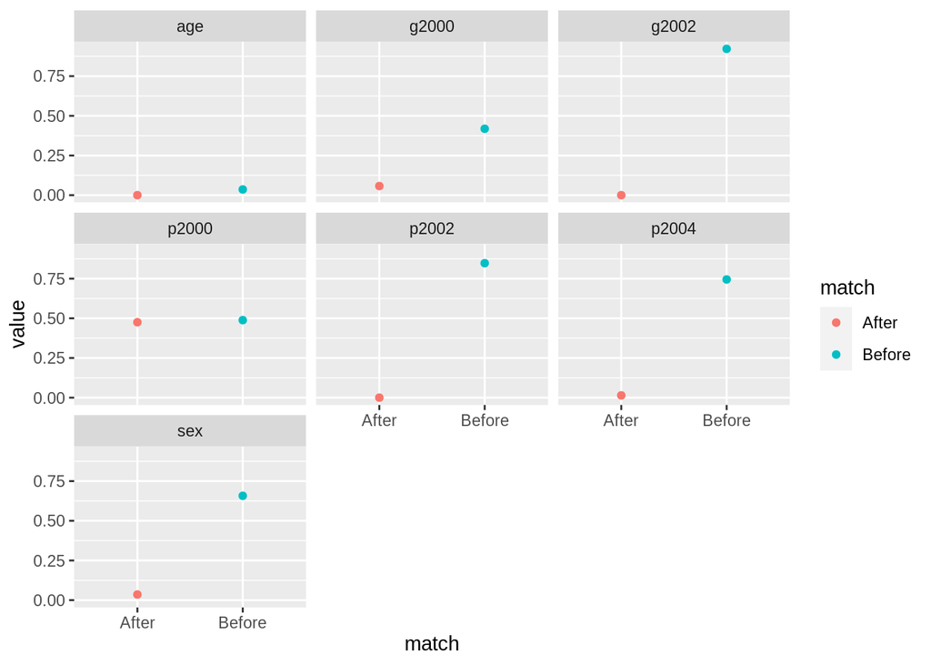

```r
ggplot(mat_bal_df, aes(x = match, y = value, group = match, fill = match, color = match)) + geom_point() + facet_wrap( ~ var)
```

## Part (b)

#### S-Learner

```r
df_learner <- gotv

#Creating a forest with the entire dataset
rf <- forestry(x = df_learner[coln[1:8]], y = df_learner$voted)

#Creating two datasets, (i) treated where all observations are considered treated (treatment = 1) and (ii) untreated where all observations are considered untreated (treatment = 0)
df_learner_treated <- df_learner
df_learner_untreated <- df_learner
df_learner_treated$treatment <- replace(df_learner$treatment,df_learner$treatment == 0, 1)
df_learner_untreated$treatment <- replace(df_learner$treatment,df_learner$treatment == 1, 0)

#Estimating outcome by assuming the all observations were treated and untreated respectively
s_pred_treated <- predict(rf, df_learner_treated[coln[1:8]])
s_pred_untreated <- predict(rf, df_learner_untreated[coln[1:8]])

#s_ite stores the difference of estimate outcome, and cate_s_learner is the treatment effect
s_ite <- s_pred_treated - s_pred_untreated
cate_s_learner <- mean(s_ite)
```

The estimate from the S-learner is 0.0100417

#### T-Learner

```r
#Creating a subsets of the dataset to split observations into treated and untreated
treated_df_learner <- df_learner[df_learner$treatment == 1,]
untreated_df_learner <- df_learner[df_learner$treatment == 0,]

#Creating two forests for treated vis-a-vis untreated datasets
treated_rf <- forestry(x = treated_df_learner[coln[1:8]], y = treated_df_learner$voted)
untreated_rf <- forestry(x = untreated_df_learner[coln[1:8]], y = untreated_df_learner$voted)

#Estimating outcome for the entire dataset based on two forests
t_pred_treatedmodel <- predict(treated_rf,df_learner[coln[1:8]])
t_pred_untreatedmodel <- predict(untreated_rf,df_learner[coln[1:8]])

#t_ite stores the difference of estimate outcome, and cate_t_learner is the treatment effect
t_ite <- t_pred_treatedmodel - t_pred_untreatedmodel
cate_t_learner <- mean(t_ite)
```

The estimate from the T-learner is 0.0181079

## Part (c)

1. In the GOTV dataset, only 16.66% of the observations are treated, and thus an estimation of treatment group will be inferior to the estimation of control group. Thus, the T-learner could be inferior.
2. Since the S-learner utilizes the complete dataset, it will have lower MSE. This is especially important since the treatment effect is close to 0.
3. Matching will be least preffered. As the number of covariates increase, the ability to correctly match observations and estimate the effect becomes difficult.

Preference:

1. For very large datasets where the number of treatment and control observations are similar, I’ll prefer the T-learner.
2. For smaller datasets and/or where the estimate is close to 0, I’ll prefer the S-learner
3. As we discussed on 31 March session, we would prefer the X-learner over T-learner in most practical situations.
4. I’ll almost never prefer Matching over S-learner or T-learner.